# Activity Monitoring

Author: Jeffrey Bosman

This report is written for Coursera’s 5th course ‘Reproducible Research’ Peer assessment in week 2. It contains an analyse of a dataset about personal movement using activity monitoring devices such as a Fitbit etc..

## Reading the data

Reading the activity.csv file as a dataframe (variable:df) is done with the following r code:

```r
Activity <- read.csv(file='activity.csv',sep = ',',header=TRUE)
df<- as.data.frame(Activity)
```

## Histogram of the total number of steps taken each day

Underneath a plot of the total steps taken each day.

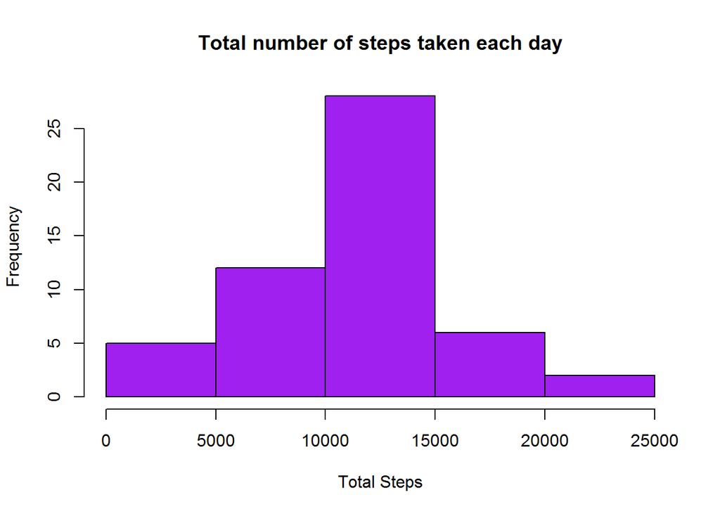

```r
library(dplyr)
TotalSteps<- df %>% filter(complete.cases(df)) %>%group_by(date) %>% summarize(TotalSteps = sum(steps))
hist(TotalSteps$TotalSteps,main='Total number of steps taken each day',col = 'purple',xlab='Total Steps')
```

```r
##dev.copy(png,'myplot1.png')  & dev.off()
```

### Mean and median total steps

mean:

```r
mean(TotalSteps$TotalSteps)
```

```
## [1] 10766.19
```

median:

```r
median(TotalSteps$TotalSteps)
```

```
## [1] 10765
```

## Avarage daily activity pattern

The avarage daily steps pattern of a human in a day.

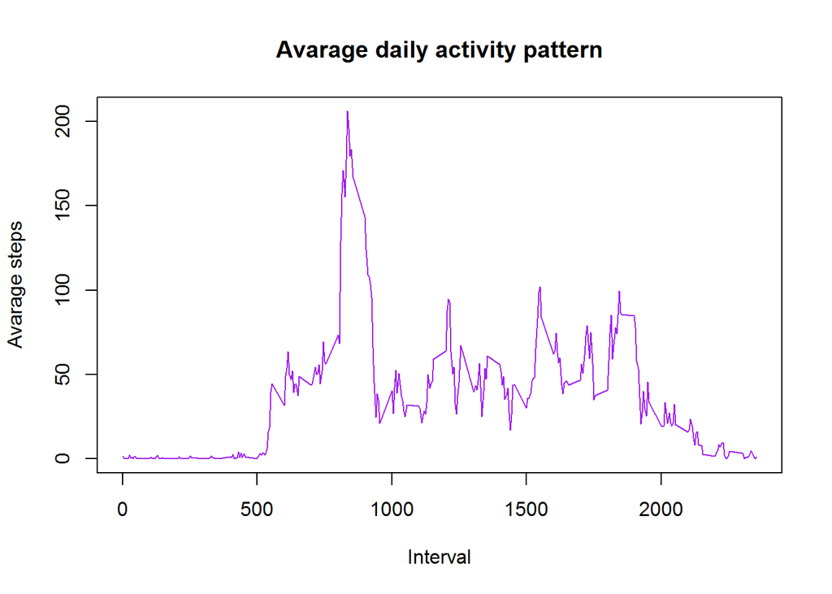

```r
TimeSeries <- df %>% filter(complete.cases(df)) %>%group_by(interval) %>% summarize(meansteps = mean(steps))

plot(TimeSeries$meansteps~TimeSeries$interval,type='l',main='Avarage daily activity pattern' , col='purple',xlab='Interval', ylab='Avarage steps')
```

```r
##dev.copy(png,'myplot2.png')  & dev.off()
```

On avarage the most steps are made in the following time interval:

```r
TimeSeries %>% arrange(desc(meansteps)) %>% filter(row_number()==1)
```

```
## # A tibble: 1 × 2
##   interval meansteps
##      <int>     <dbl>
## 1      835  206.1698
```

## Missing values

I calculate the missing values as follow:

```r
## I made the table first a matrix, just so i can assign column name to it
table<- as.matrix(table(complete.cases(df)))
colnames(table) <- 'missing?'
```

There are 2304 rows with missing values. We are going fill them with the mean of the interval.

```r
library(plyr)
##join the avarage of a interval by df
joined <- join(df,TimeSeries,by='interval',type='left')
##splits the new data into sets where steps is NA and where steps are filled
unloadNamespace("plyr") ## Unfortunately the plyr package masked the summarize function, so i unload the plr function

NoSteps <-joined[is.na(joined$steps),]
YesSteps <- joined[!is.na(joined$steps),]
##Fill the NA with the mean of the steps of a interval
means <- NoSteps$meansteps
NoSteps$steps <- means
## Generate new data set
NewData <- rbind(YesSteps,NoSteps)
NewData <- NewData[,-4]
```

## New Data histogram

First of all we do the same R statement but then with the NewData to calculate the TotalSteps taken each day.

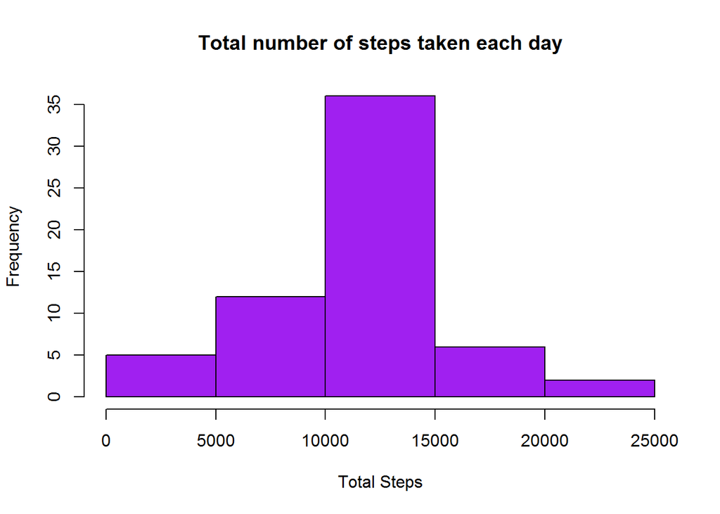

```r
TotalStepsNew<- NewData%>%group_by(date) %>% summarize(TotalStepsNew = sum(steps))

hist(TotalStepsNew$TotalStepsNew,main='Total number of steps taken each day',col = 'purple',xlab='Total Steps')
```

```r
##dev.copy(png,'myplot3.png')  & dev.off()
```

```r
mean(TotalStepsNew$TotalStepsNew)
```

```
## [1] 10766.19
```

```r
median(TotalStepsNew$TotalStepsNew)
```

```
## [1] 10766.19
```

## Are there differences in activity patterns between weekdays and weekends?

We buil a indifier for weekend and weekdays in the new data set NewData. After that we use ifelse to indify the day is weekend or the day is a weekday.

```r
NewData$ind_weekend <- weekdays(as.Date(NewData$date)) %in% c('zondag', 'zaterdag','saturday','sunday') ## my systemlanquage is dutch so i wrote it in dutch and for reproducibility in english to.

##make a function for not in
`%not in%` <- function (x, table) is.na(match(x, table, nomatch=NA_integer_))

NewData$ind_weekday <- weekdays(as.Date(NewData$date)) %not in% c('zondag', 'zaterdag','saturday','sunday')

NewData$type <- ifelse(NewData$ind_weekend ==TRUE ,'weekend','weekday')
```

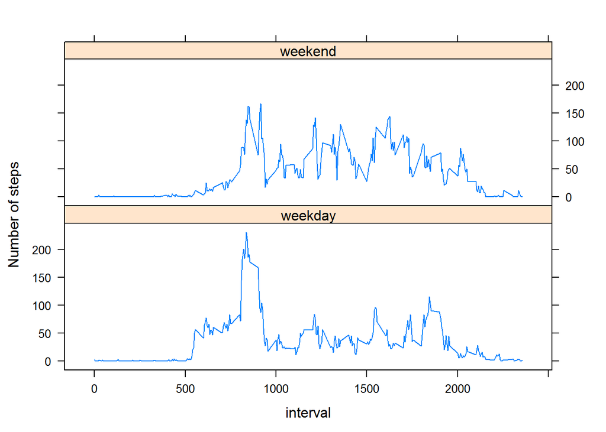

```r
library(lattice)
mean.steps.by.interval.imp <- NewData  %>%
   group_by(interval, type) %>%
   summarise(mean.steps=mean(steps))


xyplot(mean.steps~interval|type,
        type="l",
        data = mean.steps.by.interval.imp,
        layout=c(1,2),
        ylab = "Number of steps")
```

```r
##dev.copy(png,'myplot4.png')  & dev.off()
```